# Borrador

Carlos Crespín

2022-10-07

Regresiones: Carlos Daniel Crespín Juárez - 20203563

```r
library("rio")
library("dplyr")
poverty=import("https://github.com/krlos20203563/Proyecto-Grupal-Estadistica-para-el-Analisis-Politico-2/raw/main/Poverty.xls")
poverty=select(poverty, c(1, 63))
```

```r
poverty=filter(poverty, !is.na(...63))
```

```r
names(poverty)=c("Country", "Porcentpobreza2018")
```

```r
poverty=poverty[-c(1),]
```

```r
poverty$Porcentpobreza2018=as.numeric(poverty$Porcentpobreza2018)
```

```r
str(poverty)
```

```
## 'data.frame':    99 obs. of  2 variables:
##  $ Country           : chr  "Angola" "Albania" "Emiratos Árabes Unidos" "Argentina" ...
##  $ Porcentpobreza2018: num  31.1 0 0 0.8 1.3 0.5 0.6 0.1 19.9 30.5 ...
```

```r
GINI=import("https://github.com/krlos20203563/Proyecto-Grupal-Estadistica-para-el-Analisis-Politico-2/raw/main/GINI.csv")
```

```r
str(GINI)
```

```
## 'data.frame':    174 obs. of  6 variables:
##  $ name               : chr  "South Africa" "Namibia" "Zambia" "Sao Tome and Principe" ...
##  $ slug               : chr  "south-africa" "namibia" "zambia" "sao-tome-and-principe" ...
##  $ value              : num  63 59.1 57.1 56.3 54.6 54 53.9 53.9 53.3 52.1 ...
##  $ date_of_information: chr  "2014 est." "2015 est." "2015 est." "2017 est." ...
##  $ ranking            : int  1 2 3 4 5 6 7 8 9 10 ...
##  $ region             : chr  "Africa" "Africa" "Africa" "Africa" ...
```

```r
names(GINI)
```

```
## [1] "name"                "slug"                "value"
## [4] "date_of_information" "ranking"             "region"
```

```r
GINI=select(GINI, c(1, 3))
```

```r
names(GINI)=c("Country", "IndexGINI")
```

```r
Desempleo=import("https://github.com/krlos20203563/Proyecto-Grupal-Estadistica-para-el-Analisis-Politico-2/raw/main/TDESEMPLEO.xls")
Desempleo=select(Desempleo, c(1,63))
```

```r
Desempleo=filter(Desempleo, !is.na(...63))
```

```r
names(Desempleo)=c("Country", "PobUnemp2018")
```

```r
Desempleo=Desempleo[-c(1),]
```

```r
names(Desempleo)
```

```
## [1] "Country"      "PobUnemp2018"
```

```r
Desempleo$PobUnemp2018=as.numeric(Desempleo$PobUnemp2018)
```

```r
str(Desempleo)
```

```
## 'data.frame':    235 obs. of  2 variables:
##  $ Country     : chr  "Africa Eastern and Southern" "Afghanistan" "Africa Western and Central" "Angola" ...
##  $ PobUnemp2018: num  6.73 11.15 6.04 7.42 12.3 ...
```

```r
massmov=import("https://github.com/krlos20203563/Proyecto-Grupal-Estadistica-para-el-Analisis-Politico-2/raw/main/mmALL.csv")
```

```r
massmov=select(massmov, c(2, 4, 7))
```

```r
str(massmov)
```

```
## 'data.frame':    17145 obs. of  3 variables:
##  $ country      : chr  "Canada" "Canada" "Canada" "Canada" ...
##  $ year         : int  1990 1990 1990 1990 1990 1990 1991 1991 1992 1993 ...
##  $ protestnumber: int  1 2 3 4 5 6 1 2 1 1 ...
```

```r
massmov=filter(massmov, year>2018 & year<2020)
```

```r
massmov=massmov[-c(1:4, 6, 8:21, 25:28, 30:32, 34:40, 43:47, 51:54, 56:67, 71:81, 83, 85:86, 88:100, 103:116, 118, 121:151, 153:157, 160:164, 167:193, 195:196, 198:213, 215, 217:219, 221:224, 226:230, 232:238, 240:241, 243:247, 249:264, 267:284, 286:289, 291:293, 295:301, 303:304, 307:310, 312:313, 315, 318:320, 322:334, 340:341, 343, 345, 349:350, 355:357, 361:366, 369:394, 399:408, 410, 412:414, 419:422, 424:440, 446:455, 457:460, 462:463, 471, 477:485, 487:498, 500:502, 507:509, 511:513, 515:516, 519:524, 526:590, 592:594, 597:623, 625:628, 631:648, 650:652, 655:715, 728, 731:734, 736:790, 792, 796, 799:820, 823:824, 826:829, 831:838, 840:842, 844:846, 848:850, 857, 859:863),]
```

```r
str(massmov)
```

```
## 'data.frame':    159 obs. of  3 variables:
##  $ country      : chr  "Canada" "Cuba" "Haiti" "Dominican Republic" ...
##  $ year         : int  2019 2019 2019 2019 2019 2019 2019 2019 2019 2019 ...
##  $ protestnumber: int  5 2 15 0 0 5 4 8 0 6 ...
```

```r
massmov$protestnumber=as.numeric(massmov$protestnumber)
```

```r
str(massmov)
```

```
## 'data.frame':    159 obs. of  3 variables:
##  $ country      : chr  "Canada" "Cuba" "Haiti" "Dominican Republic" ...
##  $ year         : int  2019 2019 2019 2019 2019 2019 2019 2019 2019 2019 ...
##  $ protestnumber: num  5 2 15 0 0 5 4 8 0 6 ...
```

```r
massmov$year=as.numeric(massmov$year)
```

```r
str(massmov)
```

```
## 'data.frame':    159 obs. of  3 variables:
##  $ country      : chr  "Canada" "Cuba" "Haiti" "Dominican Republic" ...
##  $ year         : num  2019 2019 2019 2019 2019 ...
##  $ protestnumber: num  5 2 15 0 0 5 4 8 0 6 ...
```

```r
summary(massmov$protestnumber)
```

```
##    Min. 1st Qu.  Median    Mean 3rd Qu.    Max.
##    0.00    0.00    2.00    5.12    5.00   66.00
```

```r
massmov=select(massmov, c(1, 3))
```

```r
names(massmov)=c("Country", "protestnumber2019")
```

```r
library(stargazer)
library(knitr)
```

```r
protestas1=left_join(poverty, massmov)
str(protestas1)
```

```
## 'data.frame':    99 obs. of  3 variables:
##  $ Country           : chr  "Angola" "Albania" "Emiratos Árabes Unidos" "Argentina" ...
##  $ Porcentpobreza2018: num  31.1 0 0 0.8 1.3 0.5 0.6 0.1 19.9 30.5 ...
##  $ protestnumber2019 : num  1 17 NA 2 2 NA NA NA 27 2 ...
```

```r
protestas1=filter(protestas1, !is.na(protestnumber2019))
```

```r
protestas2=left_join(Desempleo, massmov)
str(protestas2)
```

```
## 'data.frame':    235 obs. of  3 variables:
##  $ Country          : chr  "Africa Eastern and Southern" "Afghanistan" "Africa Western and Central" "Angola" ...
##  $ PobUnemp2018     : num  6.73 11.15 6.04 7.42 12.3 ...
##  $ protestnumber2019: num  NA 1 NA 1 17 NA NA 2 2 NA ...
```

```r
protestas2=filter(protestas2, !is.na(protestnumber2019))
```

```r
protestas3=left_join(GINI, massmov)
str(protestas3)
```

```
## 'data.frame':    174 obs. of  3 variables:
##  $ Country          : chr  "South Africa" "Namibia" "Zambia" "Sao Tome and Principe" ...
##  $ IndexGINI        : num  63 59.1 57.1 56.3 54.6 54 53.9 53.9 53.3 52.1 ...
##  $ protestnumber2019: num  4 0 1 NA NA 0 3 NA 0 8 ...
```

```r
protestas3=filter(protestas3, !is.na(protestnumber2019))
```

```r
summary(protestas1$protestnumber2019)
```

```
##    Min. 1st Qu.  Median    Mean 3rd Qu.    Max.
##   0.000   1.000   2.000   8.067  11.750  56.000
```

```r
summary(protestas2$protestnumber2019)
```

```
##    Min. 1st Qu.  Median    Mean 3rd Qu.    Max.
##   0.000   0.000   2.000   5.449   5.000  66.000
```

```r
summary(protestas3$protestnumber2019)
```

```
##    Min. 1st Qu.  Median    Mean 3rd Qu.    Max.
##   0.000   0.000   2.000   5.692   5.000  66.000
```

```r
var(protestas1$protestnumber2019)
```

```
## [1] 139.9954
```

```r
var(protestas2$protestnumber2019)
```

```
## [1] 111.4492
```

```r
var(protestas3$protestnumber2019)
```

```
## [1] 113.8361
```

En este caso, en las 3 bases de datos hay sobredispersión, puesto que la varianza es mayor a la media en todos los casos

```r
modelo1=glm(protestnumber2019~Porcentpobreza2018, family = poisson(link = "log"), data = protestas1)
summary(modelo1)
```

```
##
## Call:
## glm(formula = protestnumber2019 ~ Porcentpobreza2018, family = poisson(link = "log"),
##     data = protestas1)
##
## Deviance Residuals:
##    Min      1Q  Median      3Q     Max
## -4.126  -2.892  -2.433   1.156  10.780
##
## Coefficients:
##                     Estimate Std. Error z value Pr(>|z|)
## (Intercept)         2.141934   0.082815  25.864   <2e-16 ***
## Porcentpobreza2018 -0.006066   0.006081  -0.998    0.318
## ---
## Signif. codes:  0 '***' 0.001 '**' 0.01 '*' 0.05 '.' 0.1 ' ' 1
##
## (Dispersion parameter for poisson family taken to be 1)
##
##     Null deviance: 369.09  on 29  degrees of freedom
## Residual deviance: 368.07  on 28  degrees of freedom
## AIC: 460.98
##
## Number of Fisher Scoring iterations: 6
```

```r
overdispersion=AER::dispersiontest(modelo1,alternative='greater')$ p.value<0.05
underdispersion=AER::dispersiontest(modelo1,alternative='less')$ p.value<0.05
testResult=as.data.frame(rbind(overdispersion,underdispersion))
names(testResult)='Es probable?'
testResult
```

```
##                 Es probable?
## overdispersion          TRUE
## underdispersion        FALSE
```

```r
modelo2=glm(protestnumber2019~PobUnemp2018, family = poisson(link = "log"), data = protestas2)
summary(modelo2)
```

```
##
## Call:
## glm(formula = protestnumber2019 ~ PobUnemp2018, family = poisson(link = "log"),
##     data = protestas2)
##
## Deviance Residuals:
##     Min       1Q   Median       3Q      Max
## -4.0636  -3.1227  -1.6418  -0.0092  14.1509
##
## Coefficients:
##              Estimate Std. Error z value Pr(>|z|)
## (Intercept)  1.529323   0.060246  25.385  < 2e-16 ***
## PobUnemp2018 0.022211   0.006077   3.655 0.000257 ***
## ---
## Signif. codes:  0 '***' 0.001 '**' 0.01 '*' 0.05 '.' 0.1 ' ' 1
##
## (Dispersion parameter for poisson family taken to be 1)
##
##     Null deviance: 1566.3  on 135  degrees of freedom
## Residual deviance: 1553.7  on 134  degrees of freedom
## AIC: 1864.4
##
## Number of Fisher Scoring iterations: 6
```

```r
overdispersion=AER::dispersiontest(modelo2,alternative='greater')$ p.value<0.05
underdispersion=AER::dispersiontest(modelo2,alternative='less')$ p.value<0.05
testResult=as.data.frame(rbind(overdispersion,underdispersion))
names(testResult)='Es probable?'
testResult
```

```
##                 Es probable?
## overdispersion          TRUE
## underdispersion        FALSE
```

```r
modelo3=glm(protestnumber2019~IndexGINI, family = poisson(link = "log"), data = protestas3)
summary(modelo3)
```

```
##
## Call:
## glm(formula = protestnumber2019 ~ IndexGINI, family = poisson(link = "log"),
##     data = protestas3)
##
## Deviance Residuals:
##     Min       1Q   Median       3Q      Max
## -4.2774  -3.0125  -1.7251   0.0026  12.6983
##
## Coefficients:
##             Estimate Std. Error z value Pr(>|z|)
## (Intercept)  3.08818    0.19685  15.688   <2e-16 ***
## IndexGINI   -0.03614    0.00531  -6.806    1e-11 ***
## ---
## Signif. codes:  0 '***' 0.001 '**' 0.01 '*' 0.05 '.' 0.1 ' ' 1
##
## (Dispersion parameter for poisson family taken to be 1)
##
##     Null deviance: 1534.3  on 132  degrees of freedom
## Residual deviance: 1485.2  on 131  degrees of freedom
## AIC: 1800.6
##
## Number of Fisher Scoring iterations: 6
```

```r
overdispersion=AER::dispersiontest(modelo3,alternative='greater')$ p.value<0.05
underdispersion=AER::dispersiontest(modelo3,alternative='less')$ p.value<0.05
testResult=as.data.frame(rbind(overdispersion,underdispersion))
names(testResult)='Es probable?'
testResult
```

```
##                 Es probable?
## overdispersion          TRUE
## underdispersion        FALSE
```

Como se pudo observar mediante la prueba, en los 3 modelos existe sobredispersión. En ese sentido, se realizará una regresión quasipoisson

```r
rq1=glm(protestnumber2019~Porcentpobreza2018, family = quasipoisson(link = "log"), data = protestas1)
summary(rq1)
```

```
##
## Call:
## glm(formula = protestnumber2019 ~ Porcentpobreza2018, family = quasipoisson(link = "log"),
##     data = protestas1)
##
## Deviance Residuals:
##    Min      1Q  Median      3Q     Max
## -4.126  -2.892  -2.433   1.156  10.780
##
## Coefficients:
##                     Estimate Std. Error t value Pr(>|t|)
## (Intercept)         2.141934   0.347210   6.169 1.16e-06 ***
## Porcentpobreza2018 -0.006066   0.025494  -0.238    0.814
## ---
## Signif. codes:  0 '***' 0.001 '**' 0.01 '*' 0.05 '.' 0.1 ' ' 1
##
## (Dispersion parameter for quasipoisson family taken to be 17.57788)
##
##     Null deviance: 369.09  on 29  degrees of freedom
## Residual deviance: 368.07  on 28  degrees of freedom
## AIC: NA
##
## Number of Fisher Scoring iterations: 6
```

```r
rq2=glm(protestnumber2019~PobUnemp2018, family = quasipoisson(link = "log"), data = protestas2)
summary(rq2)
```

```
##
## Call:
## glm(formula = protestnumber2019 ~ PobUnemp2018, family = quasipoisson(link = "log"),
##     data = protestas2)
##
## Deviance Residuals:
##     Min       1Q   Median       3Q      Max
## -4.0636  -3.1227  -1.6418  -0.0092  14.1509
##
## Coefficients:
##              Estimate Std. Error t value Pr(>|t|)
## (Intercept)   1.52932    0.26995   5.665 8.59e-08 ***
## PobUnemp2018  0.02221    0.02723   0.816    0.416
## ---
## Signif. codes:  0 '***' 0.001 '**' 0.01 '*' 0.05 '.' 0.1 ' ' 1
##
## (Dispersion parameter for quasipoisson family taken to be 20.07737)
##
##     Null deviance: 1566.3  on 135  degrees of freedom
## Residual deviance: 1553.7  on 134  degrees of freedom
## AIC: NA
##
## Number of Fisher Scoring iterations: 6
```

```r
rq3=glm(protestnumber2019~IndexGINI, family = quasipoisson(link = "log"), data = protestas3)
summary(rq3)
```

```
##
## Call:
## glm(formula = protestnumber2019 ~ IndexGINI, family = quasipoisson(link = "log"),
##     data = protestas3)
##
## Deviance Residuals:
##     Min       1Q   Median       3Q      Max
## -4.2774  -3.0125  -1.7251   0.0026  12.6983
##
## Coefficients:
##             Estimate Std. Error t value Pr(>|t|)
## (Intercept)  3.08818    0.83178   3.713 0.000302 ***
## IndexGINI   -0.03614    0.02244  -1.611 0.109647
## ---
## Signif. codes:  0 '***' 0.001 '**' 0.01 '*' 0.05 '.' 0.1 ' ' 1
##
## (Dispersion parameter for quasipoisson family taken to be 17.85481)
##
##     Null deviance: 1534.3  on 132  degrees of freedom
## Residual deviance: 1485.2  on 131  degrees of freedom
## AIC: NA
##
## Number of Fisher Scoring iterations: 6
```

```r
library(modelsummary)
```

Supuestos

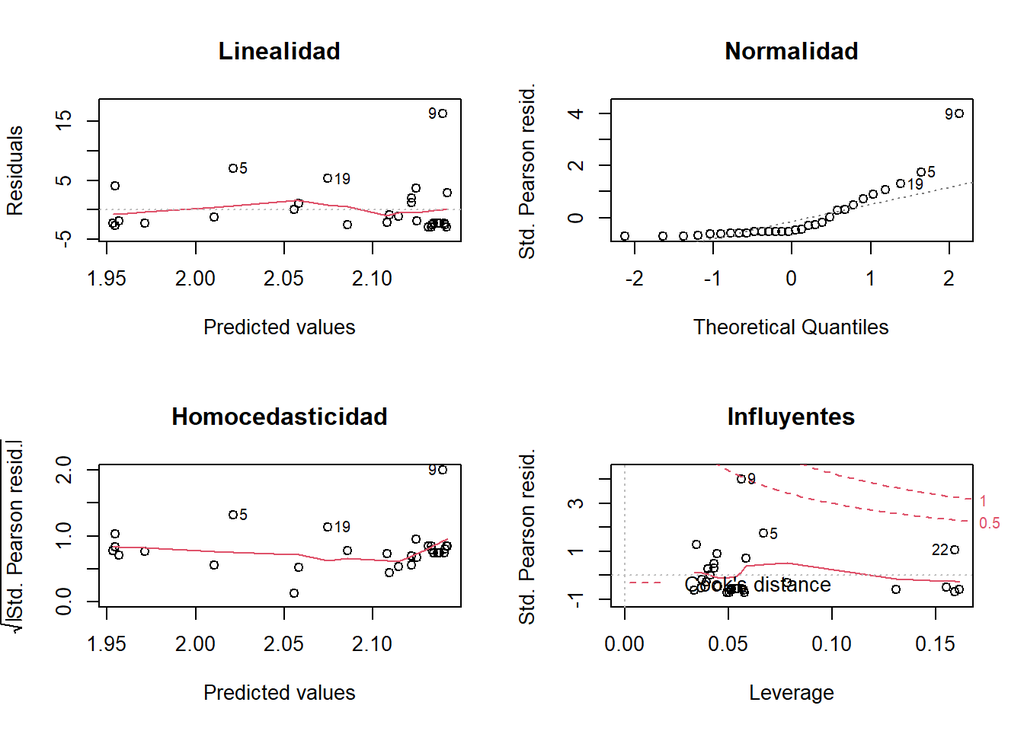

```r
par(mfrow = c(2, 2))
plot(rq1, 1,caption = '');title(main="Linealidad")
plot(rq1, 2, caption = '');title(main="Normalidad")
plot(rq1, 3, caption = '');title(main="Homocedasticidad")
plot(rq1, 5, caption = '');title(main="Influyentes")
```

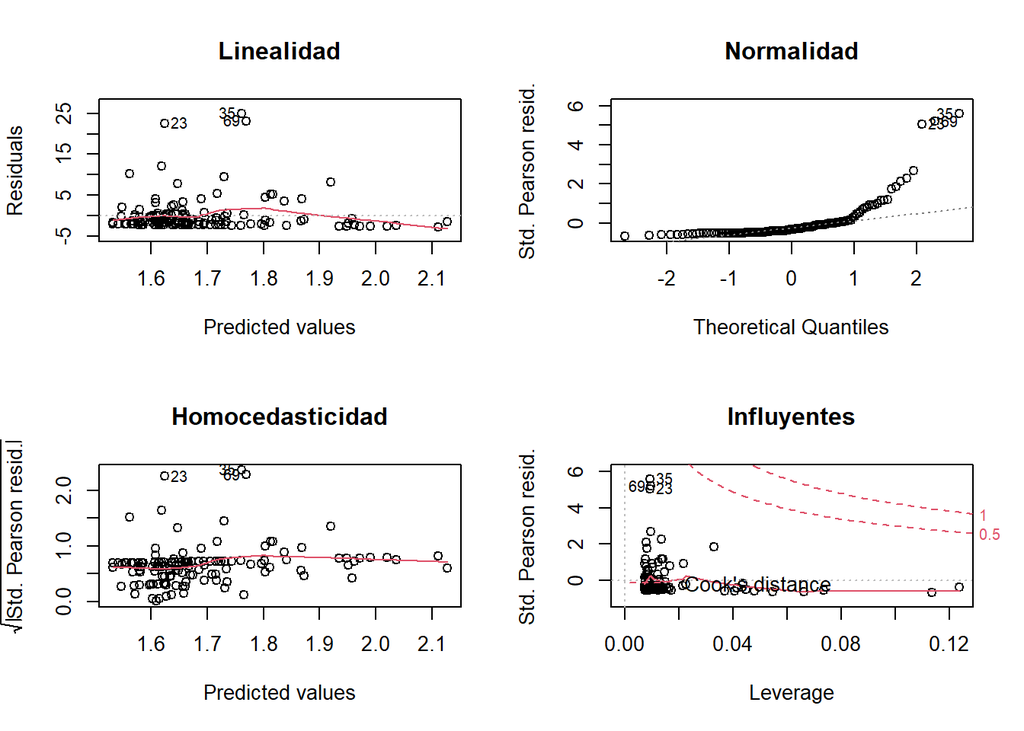

```r
par(mfrow = c(2, 2))
plot(rq2, 1,caption = '');title(main="Linealidad")
plot(rq2, 2, caption = '');title(main="Normalidad")
plot(rq2, 3, caption = '');title(main="Homocedasticidad")
plot(rq2, 5, caption = '');title(main="Influyentes")
```

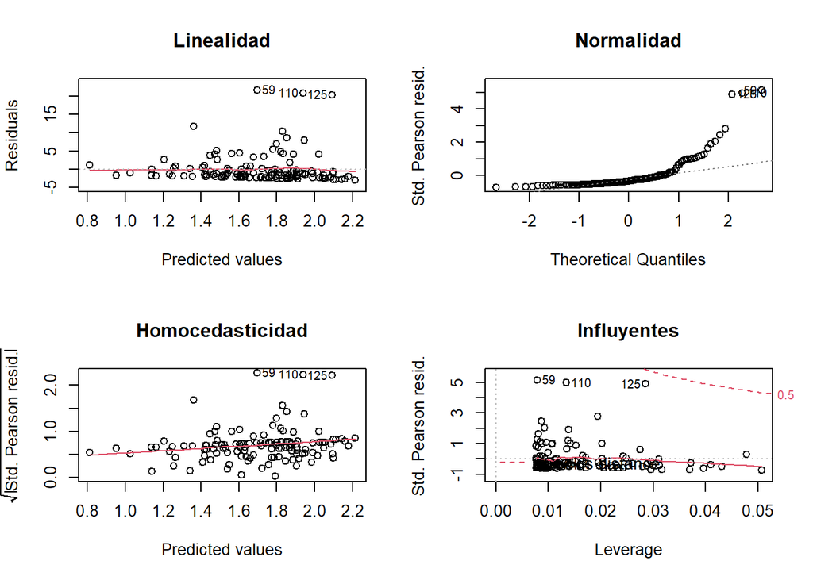

```r
par(mfrow = c(2, 2))
plot(rq3, 1,caption = '');title(main="Linealidad")
plot(rq3, 2, caption = '');title(main="Normalidad")
plot(rq3, 3, caption = '');title(main="Homocedasticidad")
plot(rq3, 5, caption = '');title(main="Influyentes")
```

Regresiones: Kevin Oscar Villareal Urquizo **Limpieza de la variable Salario mensual promedio**

```r
Salariomensual=import("https://github.com/krlos20203563/Proyecto-Grupal-Estadistica-para-el-Analisis-Politico-2/raw/main/Salariomensual.xlsx")
library(dplyr)
Salariomensual=select(Salariomensual, c(1, 3, 5, 6))
```

Filtrar filas

```r
names(Salariomensual)=c("Country", "Sex", "Time", "Dolar")
```